# Лабораторная работа №1

Dmitrii Lokshtein

8 октября 2018

## Исходные данные

Функция rexp генерирует случайные переменные при помощи экспоненциального распределения rexp(n=42, rate=5) вернёт 42 экспоненциально-распределённых числа с параметром (l) равным 5. Ели второй аргумент не указан, будет использовано значение 1 т.е. получим “стандартное экспоненциальное распределение”.

## Задание 1

1.Сгенерировал 200 случайных значений из стандартного экспоненциального распределения и сохранил в вектор exp.1. Нашёл среднее и стандартное отклонение из данных этого вектора.

```
##   [1] 0.605560656 1.598395722 0.114586020 3.298168078 2.389288096
##   [6] 0.250609034 0.411097254 1.183581050 1.221953450 3.144175112
##  [11] 0.646228500 0.248565359 1.399319412 1.639419139 0.674919419
##  [16] 1.450224793 4.700523097 1.334816798 0.954454242 2.570146507
##  [21] 0.269184921 0.404151374 2.316512617 0.921969024 4.690901953
##  [26] 2.216221543 0.260936214 0.107640915 0.181009553 2.982508138
##  [31] 0.493635426 5.037777167 0.617318798 0.135521016 0.171892371
##  [36] 0.434628419 0.524512850 0.387405419 0.172958187 0.959154817
##  [41] 0.027818597 2.123696048 0.106119120 0.638264661 1.157599661
##  [46] 0.713719826 1.484801870 0.844975333 0.797331640 0.196256598
##  [51] 1.165917501 0.168051879 0.168955912 0.100020734 0.221755273
##  [56] 0.339405966 0.548795176 0.221600756 1.692665708 0.145410019
##  [61] 0.088028493 0.108032551 0.055029919 1.800728426 3.400796294
##  [66] 0.334534323 0.469215300 1.562169953 0.482166229 0.055222585
##  [71] 2.849508606 0.753463515 1.799062578 1.393325437 2.207917953
```

[output cut: 25 more lines]

```
## [1] 0.8940123
```

```
## [1] 0.997959
```

2.Повторил, использовав следующие значения параметра l: 0.1, 0.5, 5, 10, и сохранил результаты в векторы: exp.0.1, exp.0.5, exp.5, exp.10.

```r
exp.0.1<- rexp(n=200, rate=0.1)
exp.0.5<- rexp(n=200, rate=0.5)
exp.5<- rexp(n=200, rate=5)
exp.10<- rexp(n=200, rate=10)
```

3.Построил гистограмму полученного ранее стандартного распределения.

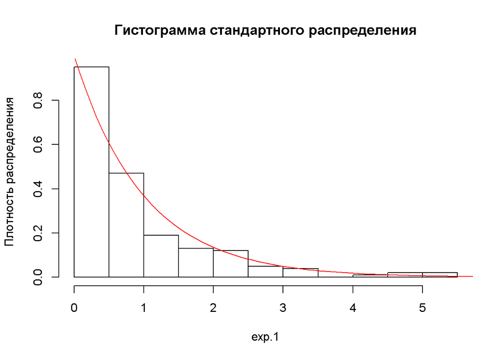

Вывод: Гистограмма соответствует виду стандартного экспоненциального распределения. Если взять большее кол-во наблюдений, то их распределение будет ближе к необходимому.

4.Построил график значений в порядке следования с помощью plot()

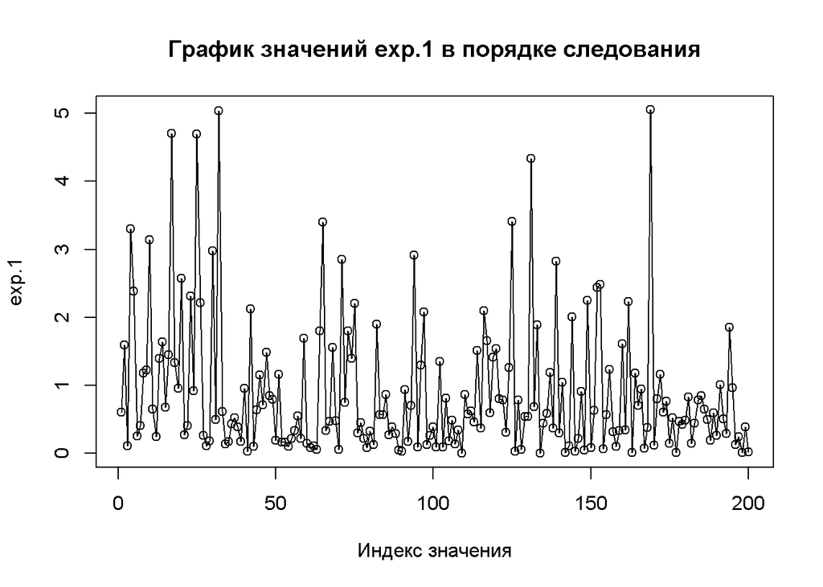

Вывод: Есть разброс значений, значения генерируются в случайном порядке.

5. Получили диаграмму рассеяния (scatterplot) векторов относительно друг друга.

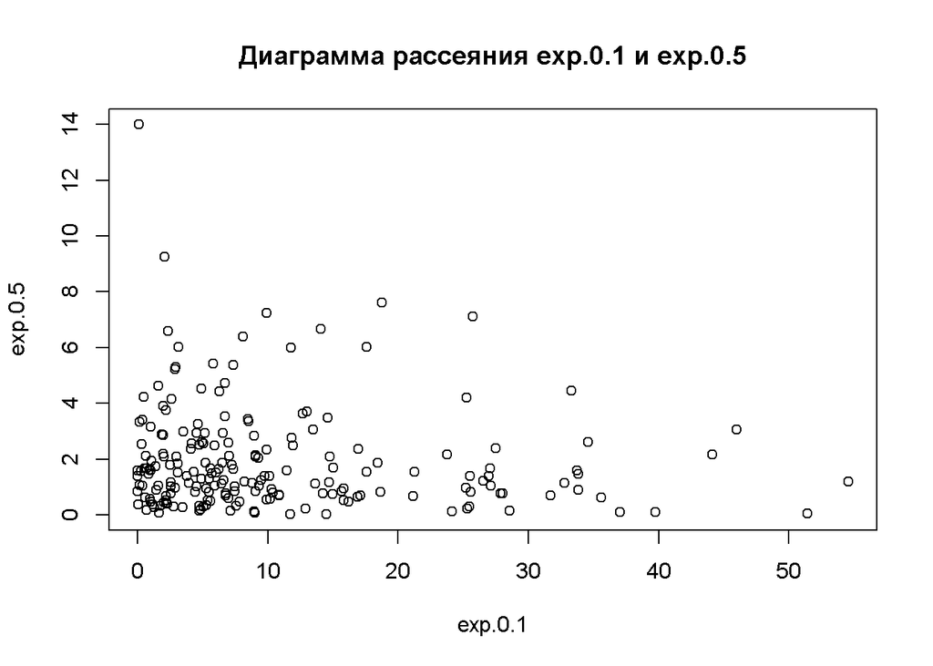

```r
plot(exp.0.1,exp.0.5,main="Диаграмма рассеяния exp.0.1 и exp.0.5")
```

Вывод: На диаграмме видно, что между векторами не наблюдается связи, так как точки далеко разбросаны по диаграмме. Таким образом, векторы экспоненциальных распределений с различными значениями l не являются зависимыми друг от друга.

6. Cравнили свойства всех наших векторов. Для начала создадим вектор, содержащий средние значения каждого из 5 полученных ранее распределений в порядке их создания. Полученный вектор сохранили в переменную exp.means.

```r
exp.means<-c(mean(exp.1),mean(exp.0.1),mean(exp.0.5),mean(exp.5),mean(exp.10))
exp.sds<-c(sd(exp.1),sd(exp.0.1),sd(exp.0.5),sd(exp.5),sd(exp.10))
exp.rate<-c(1,0.1,0.5,5,10)
```

7. Cоздали следующие диаграммы рассеяния:

Вектор с пятью средними относительно каждого из пяти векторов с различными значениями l.

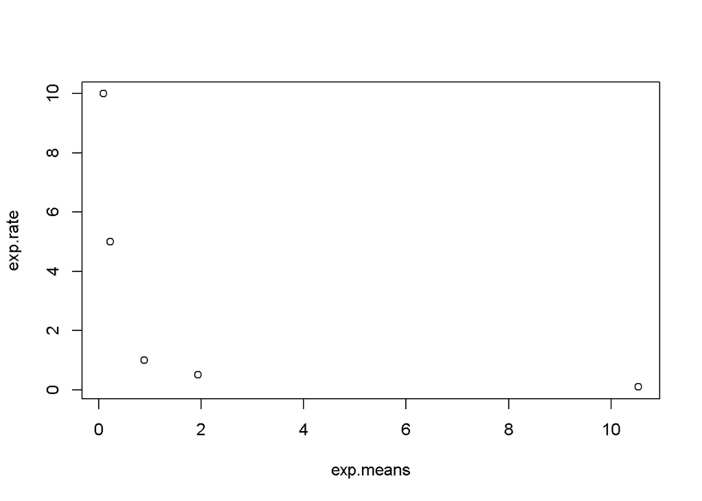

```r
plot(exp.means, exp.rate)
```

Вывод:диаграмма 1 показывает, что между вектором средних и векторами распределений с различными l нет однозначной линейной связи.

Вектор с пятью стандартными отклонениями относительно каждого из пяти векторов с различными значениями l.

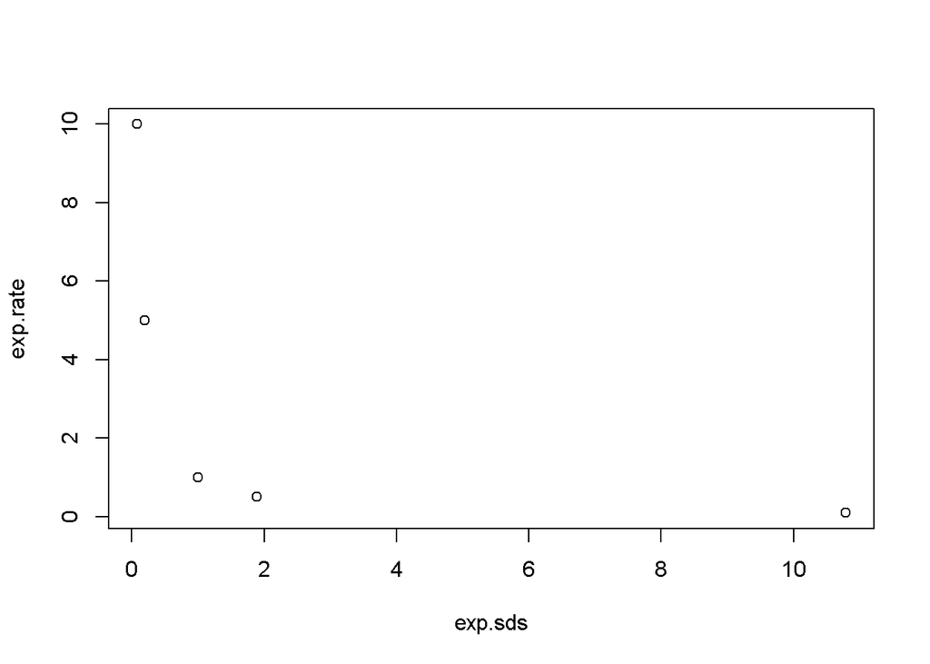

```r
plot(exp.sds, exp.rate)
```

Вектор с пятью средними относительно вектора с пятью стандартными отклонениями.

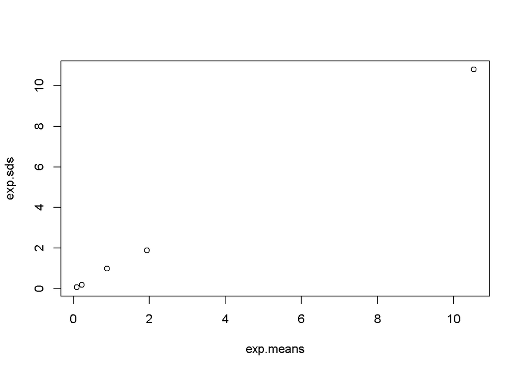

```r
plot(exp.means, exp.sds)
```

Вывод: диаграмма показывает, что между вектором средних и вектором стандратных отклонений существует однозначная линейная зависимость.

## Задание 2

1. Для демонстрации сгенеририровали 1100000 (1 млн. 100 тысяч) чисел из стандартного экспоненциального распределения и сохранили их в вектор huge.exp.1. Получили среднее и стандартное отклонение.

```r
huge.exp.1 <- rexp(n=1100000)
mean(huge.exp.1)
```

```
## [1] 0.9998614
```

```r
sd(huge.exp.1)
```

```
## [1] 1.000651
```

2. Получили гистограмму huge.exp.1.

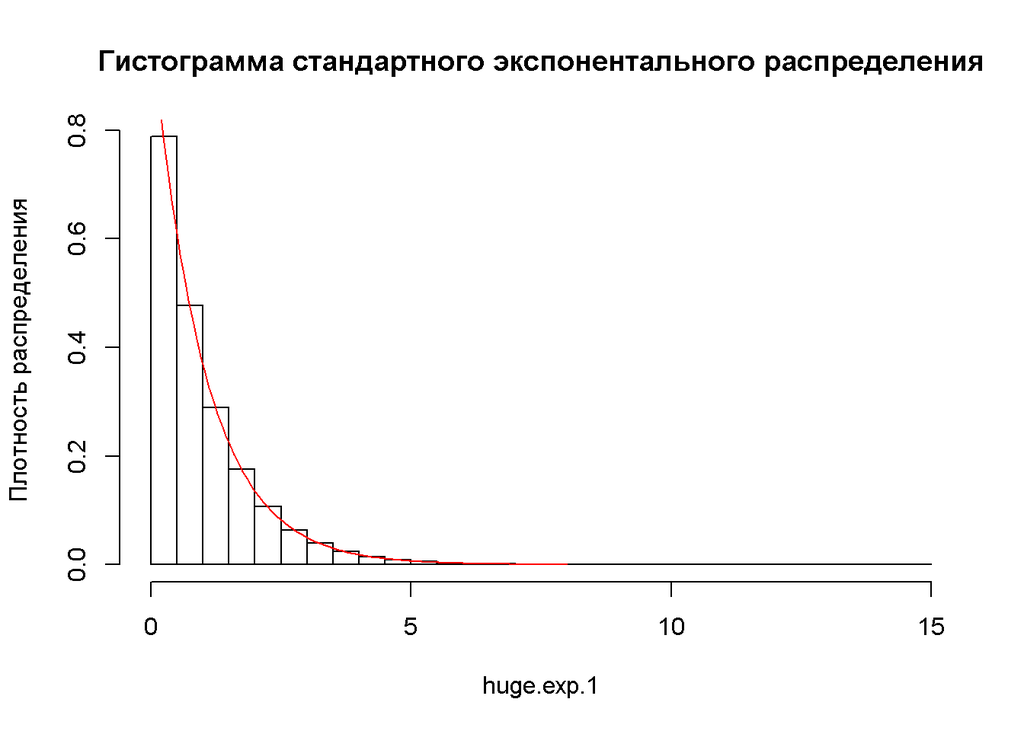

Вид полученной гистограммы действительно соответствует виду стандартного экспоненциального распределения. Отклонения от требуемого распределения стали значительно меньше по сравнению с гистограммой из предыдущего задания, => при увеличении кол-ва наблюдений, вид полученного распределения действительно приблизился к требуемому.

```r
mean.all <- mean(huge.exp.1>1)
```

4. Получили матрицу huge.exp.1.mat, содержащую 1100 строк и 1000 колонок. Построили гистограмму, использовав полученную матрицу.

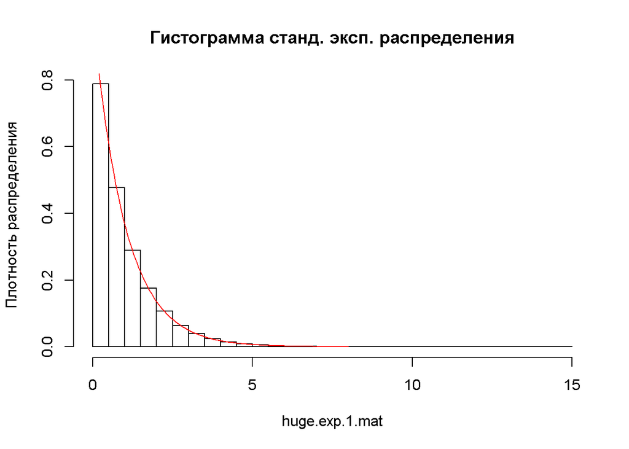

```r
huge.exp.1.mat<-matrix(huge.exp.1,nrow=1100, ncol=1000)
hist(huge.exp.1.mat, prob = TRUE, main = "Гистограмма станд. эксп. распределения", ylab="Плотность распределения")
curve(dexp(x), from = 0, to = 8, add = TRUE, col = "red")
```

Вывод: гистограмма точно такая же как и в пункте 2, а значит вид гистограммы не зависит от способа представления входных данных.

5. Рассчитали среднее 137-й колонки из huge.exp.1.mat.

```r
colMeans(huge.exp.1.mat)[137]
```

```
## [1] 1.01934
```

6. Нашла среднее всей 1000 колонок и сохранили их в вектор. Отобразили диаграмму средних значений колонок.

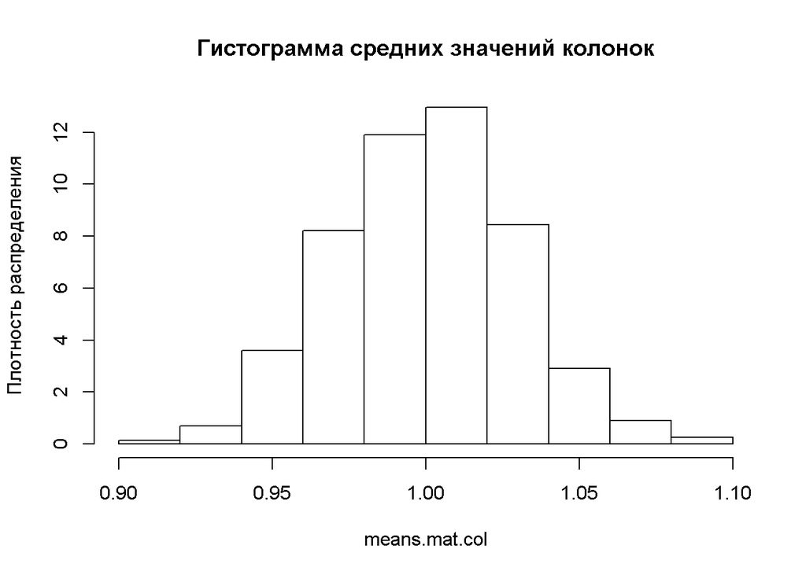

```r
means.mat.col<-colMeans(huge.exp.1.mat)
hist(means.mat.col, prob = TRUE, main = "Гистограмма средних значений колонок", ylab="Плотность распределения")
```

7. Рассчитали квадрат каждого значения из huge.exp.1 и нашли среднее и стандартное отклонение полученного вектора квадратов.

```r
squre.huge.exp.1<-huge.exp.1^2
mean(squre.huge.exp.1)
```

```
## [1] 2.001025
```

```r
sd(squre.huge.exp.1)
```

```
## [1] 4.458982
```

Вывод: С увеличением значений вектора среднее и стандартное отклонения увеличиваются.